# MTH6139 Time Series

Coursework 1

Carlota Dujo Sierra

March 2024

## 1. A Prophet’s tutorial

I found this Youtube tutorial named “Level Up Your Forecasting Skills with Facebook Prophet Model in R” where Data Heroes explain in less than 5 minutes how to use Prophet.

Prophet is a procedure for forecasting time series data based on an additive model where non-linear trends are fit with yearly, weekly, and daily seasonality, plus holiday effects. It works best with time series that have strong seasonal effects and several seasons of historical data. Prophet is robust to missing data and shifts in the trend, and typically handles outliers well.

[video not shown]

The following code is used to upload the data set, create the prophet model, perform a forecast and plot it.

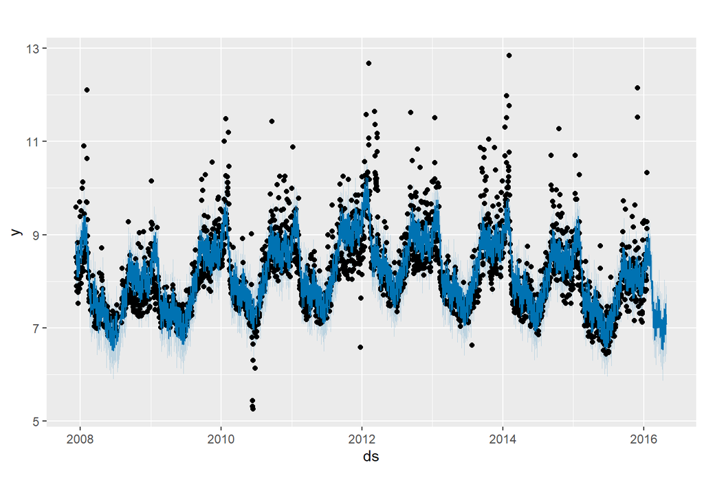

```r
df <- read_csv("df.csv")

# Prophet

m = prophet(df)

# forecasting
future = make_future_dataframe(m, periods = 100)
forecast = predict(m, future)
plot(m, forecast)
```

```r
dyplot.prophet(m, forecast)
```

[interactive chart not shown]

## 2. Airpassengers dataset analysis

The dataset is called: Monthly Airline Passenger Numbers 1949-1960 and it is available in R.

Description:

The classic Box & Jenkins airline data. Monthly totals of international airline passengers, 1949 to 1960.

Source:

Box, G. E. P., Jenkins, G. M. and Reinsel, G. C. (1976) Time Series Analysis, Forecasting and Control. Third Edition. Holden-Day. Series G.